# Reporte final TCM: Análisis de la Obesidad

### Conclusiones finales:

- La reducción de dimensionalidad con PCA ha simplificado demasiado la estructura de los datos, lo que ha afectado negativamente la precisión del modelo KNN.
- Los mejores resultados con KNN se alcanzan con valores altos de K, pero la mejora es limitada debido a la pérdida de información relevante tras aplicar PCA.
- El ajuste con el parámetro de votos mínimos (l=2) mejora la precisión, pero no soluciona por completo el problema de las asignaciones faltantes.

**Para intentar solucionar este problema, procedemos a aplicar KNN con kernel:**

```
##
## fit   1   2   3   4   5   6   7
##   1  71  19   0   0   0   1   0
##   2   7  52   3   0   0   9   4
##   3   0   6 101   2   0   3   5
##   4   0   0   1  97   0   1   1
##   5   0   0   1   0  91   0   0
##   6   1  16   5   0   0  67   9
##   7   1  10   5   0   0   5  72
```

```
## [1] 0.8273273
```

```
## Iteración: 1 de 21 Precisión: 0.8273273
## Iteración: 3 de 21 Precisión: 0.8273273
## Iteración: 5 de 21 Precisión: 0.8228228
## Iteración: 7 de 21 Precisión: 0.8153153
## Iteración: 9 de 21 Precisión: 0.8123123
## Iteración: 11 de 21 Precisión: 0.8093093
## Iteración: 13 de 21 Precisión: 0.8018018
## Iteración: 15 de 21 Precisión: 0.8003003
## Iteración: 17 de 21 Precisión: 0.7912913
## Iteración: 19 de 21 Precisión: 0.7897898
## Iteración: 21 de 21 Precisión: 0.7852853
```

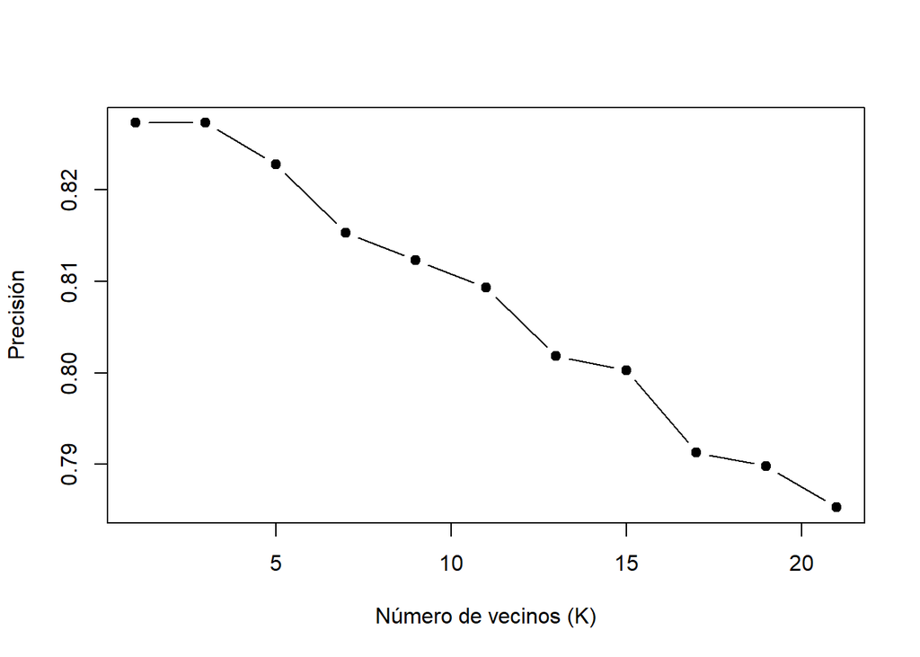

```
##        K         p
##  [1,]  1 0.8273273
##  [2,]  3 0.8273273
##  [3,]  5 0.8228228
##  [4,]  7 0.8153153
##  [5,]  9 0.8123123
##  [6,] 11 0.8093093
##  [7,] 13 0.8018018
##  [8,] 15 0.8003003
##  [9,] 17 0.7912913
## [10,] 19 0.7897898
## [11,] 21 0.7852853
```

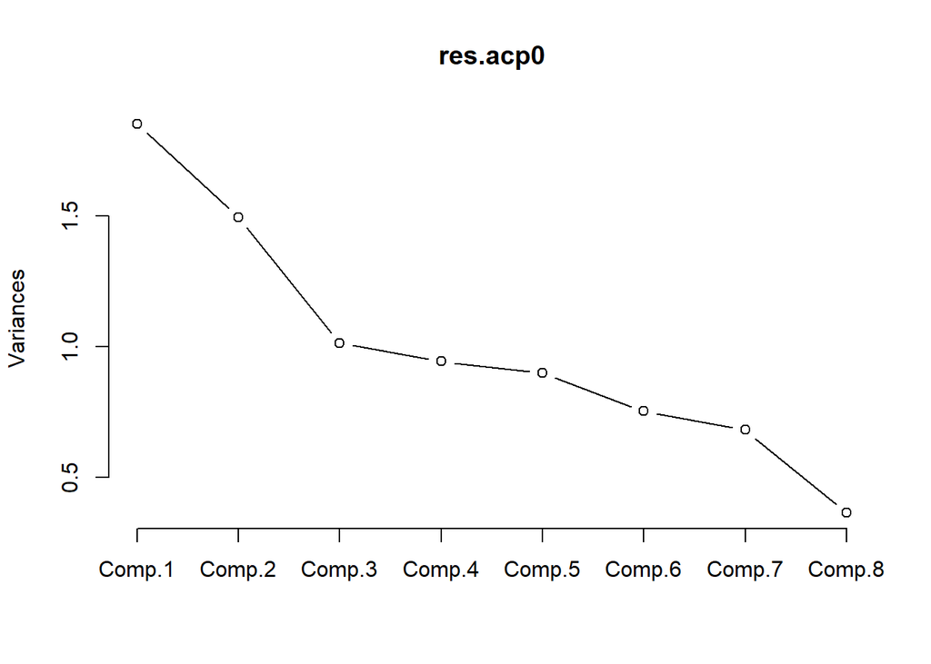

```
##
## fit  1  2  3  4  5  6  7
##   1 14 20 19  5  7  9  7
##   2  8 16 11  7  6 15 12
##   3 12 17 22 20 16 13 16
##   4  9  7 18 27 13  6 10
##   5  9  9 14 17 29 10 14
##   6 16 16 15 13 11 17 15
##   7 12 18 17 10  9 16 17
```

```
## [1] 0.2132132
```

```
## Iteración: 1 de 21
## Iteración: 3 de 21
## Iteración: 5 de 21
## Iteración: 7 de 21
## Iteración: 9 de 21
## Iteración: 11 de 21
## Iteración: 13 de 21
## Iteración: 15 de 21
## Iteración: 17 de 21
## Iteración: 19 de 21
## Iteración: 21 de 21
```

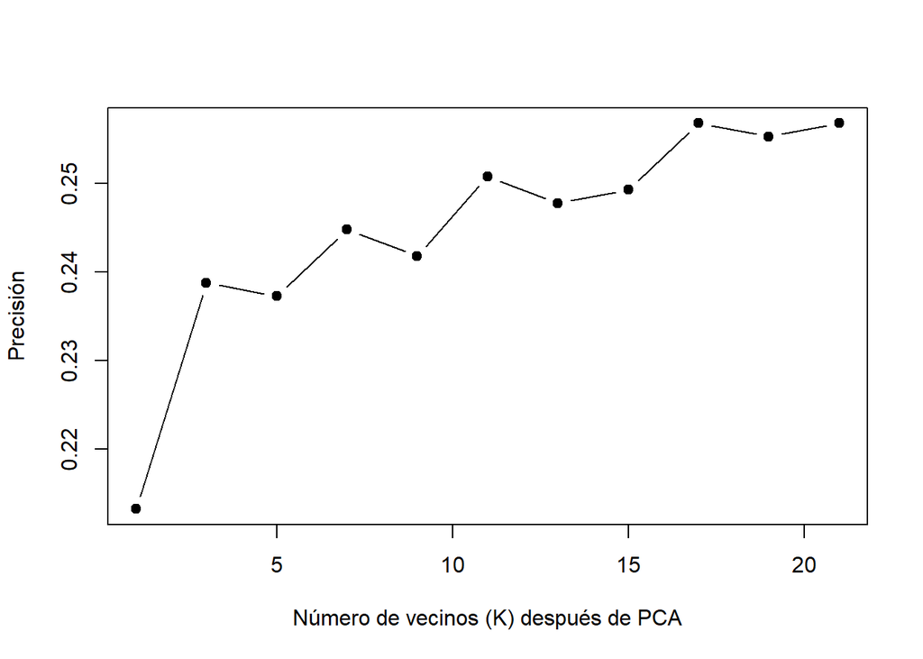

```
##        K         p
##  [1,]  1 0.2132132
##  [2,]  3 0.2387387
##  [3,]  5 0.2372372
##  [4,]  7 0.2447447
##  [5,]  9 0.2417417
##  [6,] 11 0.2507508
##  [7,] 13 0.2477477
##  [8,] 15 0.2492492
##  [9,] 17 0.2567568
## [10,] 19 0.2552553
## [11,] 21 0.2567568
```

### Interpretación de los resultados obtenidos con KNN utilizando kernel

Después de aplicar KNN con kernel en nuestro dataset de obesidad, hemos obtenido resultados que nos permiten evaluar la precisión del modelo, la elección del número de vecinos (K) y el impacto de la reducción de dimensionalidad con PCA.

#### 1. KNN con kernel sobre datos originales

Resultados de la matriz de confusión con K=1:

sum(diag(t))/sum(t) = 0.8273 (82.73% precisión)

Al aplicar KNN con kernel (k=1), se obtuvo una precisión del 82.73%, lo cual es un buen resultado inicial.

Esto indica que el uso de kernel mejora la capacidad del modelo para separar clases, sobre todo en categorías con más observaciones.

El clasificador muestra buen ajuste sin necesidad de parámetros adicionales ni ponderaciones.

#### 2. Evaluación de diferentes valores de K en KNN

Resultados de precisión para distintos valores de K:

| K | p |
| --- | --- |
| 1 | 0.8273273 |
| 3 | 0.8273273 |
| 5 | 0.8228228 |
| 7 | 0.8153153 |
| 9 | 0.8123123 |
| 11 | 0.8093093 |
| 13 | 0.8018018 |
| 15 | 0.8003003 |
| 17 | 0.7912913 |
| 19 | 0.7897898 |
| 21 | 0.7852853 |

- Se observó que la precisión disminuye gradualmente al aumentar K.
- El mejor rendimiento se mantuvo en K=1 y K=3, confirmando que pocos vecinos funcionan mejor en este caso.

Interpretación: cuanto más se promedia con vecinos más lejanos, más se diluyen las diferencias entre clases.

#### 3. Aplicación de PCA

Resultados de precisión tras PCA:

sum(diag(t))/sum(t) = 0.2132 (21.32% precisión)

#### 4. Comparación de K tras PCA

También se probaron varios valores de K con los datos transformados por PCA:

| K | p |
| --- | --- |
| 1 | 0.2132132 |
| 3 | 0.2387387 |
| 5 | 0.2372372 |
| 7 | 0.2447447 |
| 9 | 0.2417417 |
| 11 | 0.2507508 |
| 13 | 0.2477477 |
| 15 | 0.2492492 |
| 17 | 0.2567568 |
| 19 | 0.2552553 |
| 21 | 0.2567568 |

#### Interpretación: aunque se recupera algo de precisión con K más altos, nunca se alcanza el rendimiento original sin PCA.

### Conclusiones del análisis KNN:

1. KNN con kernel sin PCA es la mejor configuración

Precisión máxima del 82.73% con K=1. El modelo es estable, simple y efectivo.

2. PCA no aporta mejoras en este caso

La reducción de dimensiones elimina información clave. Aunque visualmente sea útil, no mejora la clasificación.

3. El valor óptimo de K es bajo (1 o 3)

Más vecinos reducen la precisión por sobreajuste con clases cercanas pero diferentes.

4. El uso de kernel es útil, pero no crítico

Mejora la separación entre clases, especialmente cuando los datos no son lineales. Pero no cambia drásticamente el rendimiento respecto al KNN estándar.

5. Tipo de KNN utilizado

Se usó una versión básica: sin ponderación por distancia, sin rechazo, sin ajuste de pesos por variable. Aun así, el modelo funcionó bien, lo que refuerza que los datos son informativos.

# 4. Aplicación de Naive Bayes.

```
## Precisión general = 66.25 %
```

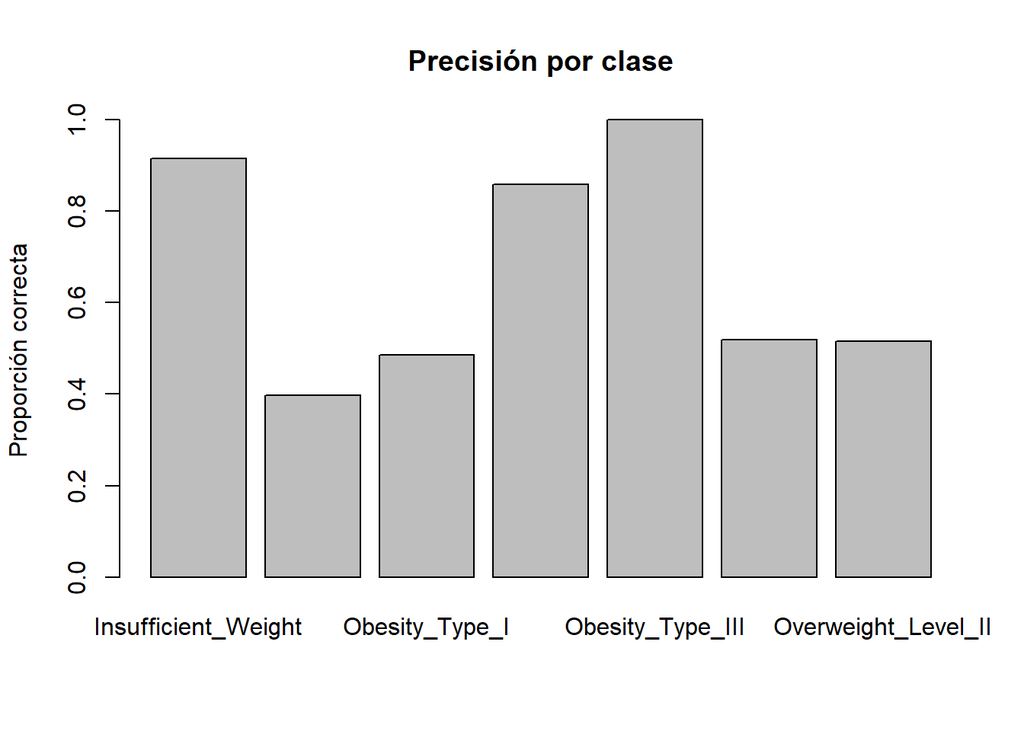

Se entrenó un modelo de clasificación Naive Bayes para predecir la categoría de obesidad (NObeyesdad) a partir de variables relacionadas con hábitos alimentarios, actividad física, consumo de agua, edad, entre otras. El conjunto de datos se dividió en un 70% para entrenamiento y un 30% para prueba.

El modelo alcanzó una precisión general del 66.25%, lo que significa que aproximadamente 2 de cada 3 observaciones del conjunto de prueba fueron correctamente clasificadas. Este rendimiento es razonable considerando la naturaleza multiclase del problema y la simplicidad del modelo.

El análisis de precisión por clase, mostrado en el gráfico correspondiente, revela que el modelo tiene un rendimiento desigual entre las distintas categorías:

Las clases Obesity_Type_III e Insufficient_Weight se clasifican con alta precisión, lo que sugiere que sus perfiles son suficientemente distintos para que el modelo los detecte con claridad.

En cambio, Obesity_Type_I, Overweight_Level_II y otras clases intermedias muestran precisiones considerablemente más bajas, cercanas al 50%. Esto podría deberse a la similitud entre estas clases, lo que dificulta su separación, especialmente bajo el supuesto de independencia entre predictores que impone Naive Bayes.

Este comportamiento es habitual en modelos Naive Bayes aplicados a variables que no son completamente independientes, lo que puede limitar su rendimiento. Sin embargo, su rapidez, facilidad de interpretación y eficiencia computacional lo convierten en una herramienta útil como clasificador base.

### Importancia de Variables y Comparación con Baseline

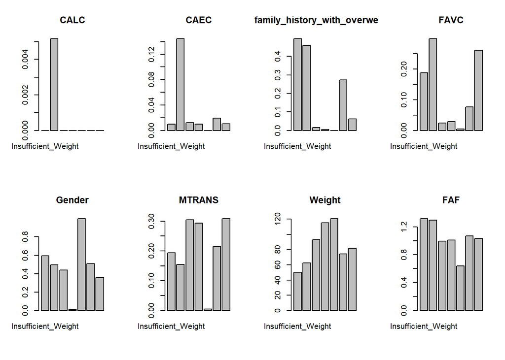

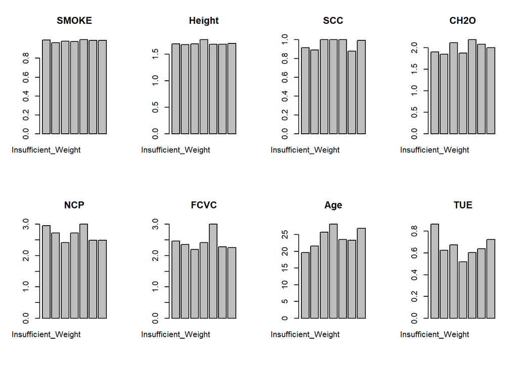

```
##
## Naive Bayes: 66.25 %
```

```
## Baseline    : 16.56 %
```

```
## Ganancia    : 49.68 puntos
```

Para interpretar el modelo Naive Bayes, se utilizó una medida simple de importancia de variables basada en el índice de Gini aplicado a las medias o probabilidades condicionales de cada predictor. Esta métrica indica qué tan desbalanceadas son las distribuciones por clase para cada variable, y por tanto, qué tan informativas son para el modelo.

Los resultados muestran que las variables más importantes son principalmente categóricas o ordinales. Las más destacadas incluyen:

family_history_with_overweight, que presenta una clara diferenciación entre categorías en función de la clase de obesidad.

Weight, como era esperable, es una variable crítica para predecir la categoría de IMC.

FAVC (frecuencia de consumo de comida rápida) y CAEC (consumo entre comidas) también muestran distribuciones muy sesgadas por clase, lo que sugiere su papel clave en la clasificación.

Otras variables como FAF (actividad física), MTRANS (tipo de transporte), y Gender también aportan discriminación significativa.

Estas variables contribuyen de forma crucial a la predicción del modelo y permiten entender qué características están asociadas a los distintos tipos de obesidad.

En paralelo, se comparó el rendimiento del modelo Naive Bayes con un clasificador base, que simplemente asigna a todos los individuos la clase mayoritaria (baseline). Este clasificador alcanzó una precisión de apenas 16.56%, lo cual es consistente con un problema multiclase con clases desbalanceadas.

En cambio, el modelo Naive Bayes logró una precisión del 66.25%, lo que representa una ganancia de 49.68 puntos porcentuales con respecto al baseline. Esta mejora sustancial demuestra que el modelo realmente captura información relevante de las variables predictoras y que su desempeño está lejos de ser trivial.

# 5. Aplicación de Random Forest

Para analizar y predecir el nivel de obesidad en individuos a partir de variables relacionadas con sus hábitos alimenticios y físicos, se utilizó el algoritmo de Random Forest. Este método de aprendizaje automático pertenece a la familia de los clasificadores de conjunto y está basado en la construcción de múltiples árboles de decisión. Cada árbol es entrenado sobre una muestra aleatoria del conjunto de datos original mediante bootstrap, y para cada división interna del árbol se selecciona un subconjunto aleatorio de variables, reduciendo así la correlación entre árboles y aumentando la robustez del modelo.

Posteriormente, se dividió el conjunto de datos en dos subconjuntos: un 70% para entrenamiento y un 30% para prueba. Esta división permite construir el modelo sobre una porción representativa de los datos, y evaluar su capacidad predictiva de forma objetiva utilizando datos no vistos durante el entrenamiento.

### Distribución de clases

Proporción de clases en el conjunto de prueba

| Clase | Proporción |
| --- | --- |
| Insufficient_Weight | 0.1201 |
| Normal_Weight | 0.1547 |
| Obesity_Type_I | 0.1742 |
| Obesity_Type_II | 0.1486 |
| Obesity_Type_III | 0.1366 |
| Overweight_Level_I | 0.1291 |
| Overweight_Level_II | 0.1366 |

Como se observa en la tabla anterior, las clases no están perfectamente balanceadas: la proporción de observaciones varía entre aproximadamente 12% y 17% según la clase. Por tanto, la expectativa de precisión para un clasificador aleatorio no es del 14.3% (1/7) como sería en un problema simétrico, sino que dependería de la estrategia de predicción utilizada.

En el caso más simple, un clasificador ingenuo que siempre predijera la clase más frecuente (Obesity_Type_I, con ~17.4%) alcanzaría una precisión similar a esa proporción. Por tanto, cualquier modelo que se pretenda útil debe mejorar sensiblemente ese umbral. Este tipo de análisis es clave para interpretar correctamente el rendimiento del modelo, especialmente en contextos de clases desbalanceadas.

### Árboles condicionales

[figure not shown]

```
##
## pred.ct               Insufficient_Weight Normal_Weight Obesity_Type_I
##   Insufficient_Weight                  80            22              0
##   Normal_Weight                         0            37              0
##   Obesity_Type_I                        0             0             74
##   Obesity_Type_II                       0             0              8
##   Obesity_Type_III                      0             0              4
##   Overweight_Level_I                    0            44              0
##   Overweight_Level_II                   0             0             30
##
## pred.ct               Obesity_Type_II Obesity_Type_III Overweight_Level_I
##   Insufficient_Weight               0                0                  0
##   Normal_Weight                     0                0                  1
##   Obesity_Type_I                    1                0                  0
##   Obesity_Type_II                  95                0                  0
##   Obesity_Type_III                  2               91                  0
##   Overweight_Level_I                0                0                 78
##   Overweight_Level_II               1                0                  7
##
## pred.ct               Overweight_Level_II
##   Insufficient_Weight                   0
##   Normal_Weight                         0
##   Obesity_Type_I                        9
##   Obesity_Type_II                       0
##   Obesity_Type_III                      0
##   Overweight_Level_I                   31
##   Overweight_Level_II                  51
```

```
## [1] "Conditional Tree Accuracy: 0.7598"
```

El algoritmo ctree construye árboles de decisión basados en test estadísticos (tests de independencia) en lugar de medidas heurísticas como la ganancia de información. Esto lo hace más robusto frente a variables irrelevantes o altamente correlacionadas. Es especialmente útil cuando se busca interpretar resultados de forma clara.

Las ramas del árbol representan decisiones binarias (por ejemplo, “¿el peso es menor o igual a 99 kg?”). Al llegar a los nodos terminales, el árbol asigna una clase predicha basada en la mayoría de ejemplos que cayeron en esa hoja.

La precisión obtenida por el modelo ctree fue de 0.76 (75.98%), un valor considerablemente superior al de una predicción aleatoria. En un problema de clasificación multiclase con 7 categorías, la expectativa de acierto aleatorio sería de aproximadamente 14.28%, siempre que las clases estuvieran balanceadas. Por tanto, este resultado sugiere que el modelo sí ha logrado capturar ciertos patrones relevantes en los datos.

Sin embargo, al observar la visualización del árbol, se evidencia una estructura algo compleja, con muchas ramificaciones que podrían reflejar sobreajuste. Aunque el modelo alcanza una buena precisión en el conjunto de prueba, conviene tener precaución: un árbol muy ajustado a los datos de entrenamiento puede no generalizar bien en otros contextos. Además, dado que las clases no están perfectamente balanceadas, es recomendable complementar esta métrica con otras como la matriz de confusión o el F1-score por clase, para evaluar mejor el rendimiento en cada categoría.

### Random Forest

```
##
## Call:
##  randomForest(formula = ObesityBinary ~ ., data = train, importance = TRUE,      ntree = 100)
##                Type of random forest: classification
##                      Number of trees: 100
## No. of variables tried at each split: 2
##
##         OOB estimate of  error rate: 5.88%
## Confusion matrix:
##                     Insufficient_Weight Normal_Weight Obesity_Type_I
## Insufficient_Weight                 186             6              0
## Normal_Weight                         3           166              0
## Obesity_Type_I                        0             2            226
## Obesity_Type_II                       0             0              1
## Obesity_Type_III                      0             0              0
## Overweight_Level_I                    0            17              0
## Overweight_Level_II                   0             9              7
##                     Obesity_Type_II Obesity_Type_III Overweight_Level_I
## Insufficient_Weight               0                0                  0
## Normal_Weight                     0                0                 13
## Obesity_Type_I                    1                1                  0
## Obesity_Type_II                 197                0                  0
## Obesity_Type_III                  0              233                  0
## Overweight_Level_I                0                0                174
## Overweight_Level_II               0                0                  5
##                     Overweight_Level_II class.error
## Insufficient_Weight                   0 0.031250000
## Normal_Weight                         2 0.097826087
## Obesity_Type_I                        5 0.038297872
## Obesity_Type_II                       0 0.005050505
## Obesity_Type_III                      0 0.000000000
## Overweight_Level_I                   13 0.147058824
## Overweight_Level_II                 178 0.105527638
```

```
##
## pred.rf               Insufficient_Weight Normal_Weight Obesity_Type_I
##   Insufficient_Weight                  76             4              0
##   Normal_Weight                         4            95              1
##   Obesity_Type_I                        0             0            112
##   Obesity_Type_II                       0             0              2
##   Obesity_Type_III                      0             0              1
##   Overweight_Level_I                    0             3              0
##   Overweight_Level_II                   0             1              0
##
## pred.rf               Obesity_Type_II Obesity_Type_III Overweight_Level_I
##   Insufficient_Weight               0                0                  0
##   Normal_Weight                     1                0                 12
##   Obesity_Type_I                    0                0                  0
##   Obesity_Type_II                  98                0                  0
##   Obesity_Type_III                  0               91                  0
##   Overweight_Level_I                0                0                 70
##   Overweight_Level_II               0                0                  4
##
## pred.rf               Overweight_Level_II
##   Insufficient_Weight                   0
##   Normal_Weight                         2
##   Obesity_Type_I                        5
##   Obesity_Type_II                       0
##   Obesity_Type_III                      0
##   Overweight_Level_I                    4
##   Overweight_Level_II                  80
```

```
## [1] "Random Forest Accuracy: 0.9339"
```

Se entrenó un modelo de Random Forest para predecir la variable ObesityBinary (que en este caso parece representar múltiples clases relacionadas con distintos niveles de obesidad y peso saludable). El modelo fue construido utilizando 100 árboles de decisión, y el número de variables consideradas en cada división (mtry) fue 2, que es un valor típico recomendado por defecto para clasificación.

Al finalizar el entrenamiento, se observó que el error OOB (Out-of-Bag) fue de aproximadamente 5.88%, lo cual indica que el modelo generaliza bien incluso sin usar un conjunto de prueba externo. Este valor refleja el rendimiento esperado del modelo cuando se enfrenta a nuevos datos, basado en observaciones que no se usaron en la construcción de cada árbol individual.

Cuando se aplicó el modelo al conjunto de prueba, se obtuvo una precisión del 93.39%, lo cual es un resultado muy sólido para un problema de clasificación multiclase con 7 categorías. La matriz de confusión sobre los datos de prueba confirma esta robustez: la mayoría de las clases fueron correctamente identificadas. Por ejemplo, Obesity_Type_I, Obesity_Type_II y Obesity_Type_III se clasificaron con casi total precisión. La mayor parte de los errores se concentraron en las clases de sobrepeso (Overweight_Level_I y Overweight_Level_II), lo que nuevamente puede deberse a la similitud entre estas categorías en los datos.

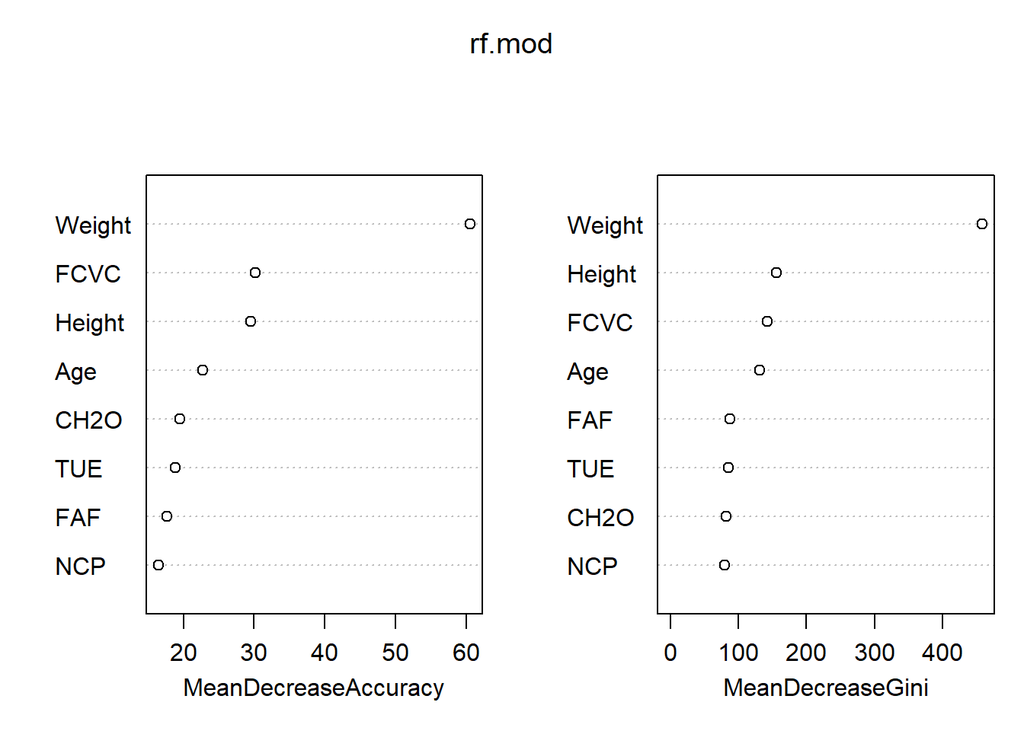

La gráfica presentada muestra la importancia de las variables predictoras utilizadas por el modelo de Random Forest para clasificar los diferentes niveles de obesidad. Esta visualización está dividida en dos paneles: a la izquierda se observa la métrica MeanDecreaseAccuracy, que indica cuánto disminuye la precisión del modelo al eliminar una determinada variable, y a la derecha se muestra MeanDecreaseGini, que representa el impacto de cada variable en la pureza de las divisiones dentro de los árboles.

En ambos casos, la variable Weight (peso) aparece como la más determinante del modelo. Esto significa que el peso corporal es el factor que más contribuye tanto a la precisión global como a las decisiones internas de los árboles que componen el bosque. Su influencia es significativamente mayor en comparación con el resto de variables, lo cual es coherente dado que el peso está directamente relacionado con los diferentes niveles de obesidad.

Otras variables como FCVC (frecuencia de consumo de verduras), Height (altura) y Age (edad) también muestran una contribución importante, aunque considerablemente menor que Weight. Estas variables aportan información complementaria al modelo, ayudando a distinguir entre clases más cercanas entre sí, como los distintos tipos de sobrepeso y obesidad. Por otro lado, variables como CH2O (consumo de agua), TUE (uso de tecnología), FAF (actividad física) y NCP (número de comidas) presentan una menor relevancia tanto en términos de precisión como de estructura del árbol. Aunque estas variables pueden tener cierto valor explicativo, su aporte al modelo de predicción es limitado en comparación con las anteriores.

En conjunto, esta interpretación sugiere que el modelo está capturando correctamente los principales factores que determinan el nivel de obesidad. El peso destaca como la variable más crítica, y las demás variables relacionadas con la alimentación y características físicas aportan información complementaria útil. Esta información no solo es valiosa desde un punto de vista técnico para ajustar o simplificar el modelo, sino también desde una perspectiva interpretativa para comprender qué factores tienen más impacto en los niveles de obesidad.

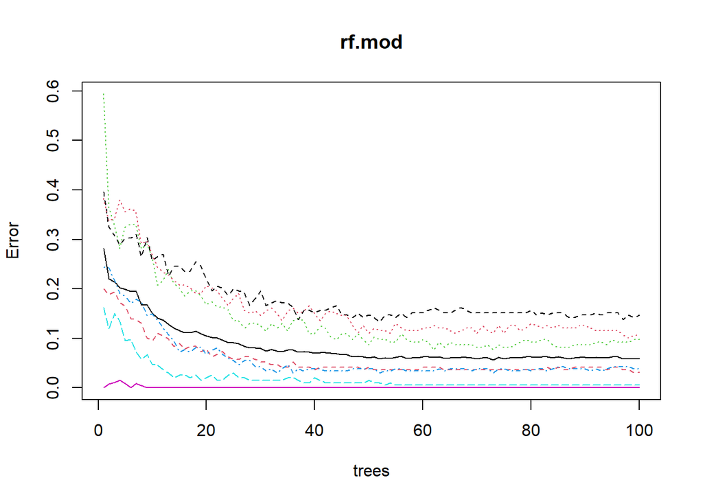

Al observar el gráfico, se aprecia que el error total disminuye rápidamente en los primeros 20-30 árboles y luego se estabiliza, oscilando ligeramente a medida que se añaden más árboles. Esto indica que el modelo aprende patrones útiles rápidamente, y que entrenar más de 50 árboles no ofrece mejoras significativas adicionales en términos de precisión. Las líneas correspondientes a cada clase muestran una tendencia similar: el error por clase disminuye y se mantiene estable, aunque en algunas clases puede haber más oscilación, lo cual es esperable si tienen menos observaciones.

En resumen, este gráfico confirma que el modelo de Random Forest con 100 árboles está bien calibrado. El error se estabiliza de manera consistente, y no se observa un sobreajuste ni un aumento del error con el aumento de árboles. Este comportamiento sugiere que el número de árboles elegido es adecuado, y que el modelo es robusto y generaliza bien a nuevos datos.

#### Random Forest: predicción sin “Peso”

```
## [1] "Random Forest Accuracy (sin peso): 0.8348"
```

```
##                      Reference
## Prediction            Insufficient_Weight Normal_Weight Obesity_Type_I
##   Insufficient_Weight                  65             5              1
##   Normal_Weight                         8            73             10
##   Obesity_Type_I                        3            10            100
##   Obesity_Type_II                       0             1              1
##   Obesity_Type_III                      2             0              1
##   Overweight_Level_I                    1             7              1
##   Overweight_Level_II                   1             7              2
##                      Reference
## Prediction            Obesity_Type_II Obesity_Type_III Overweight_Level_I
##   Insufficient_Weight               0                0                  2
##   Normal_Weight                     2                1                 13
##   Obesity_Type_I                    0                0                  7
##   Obesity_Type_II                  95                0                  4
##   Obesity_Type_III                  0               90                  0
##   Overweight_Level_I                0                0                 58
##   Overweight_Level_II               2                0                  2
##                      Reference
## Prediction            Overweight_Level_II
##   Insufficient_Weight                   1
##   Normal_Weight                         3
##   Obesity_Type_I                        6
##   Obesity_Type_II                       2
##   Obesity_Type_III                      0
##   Overweight_Level_I                    4
##   Overweight_Level_II                  75
```

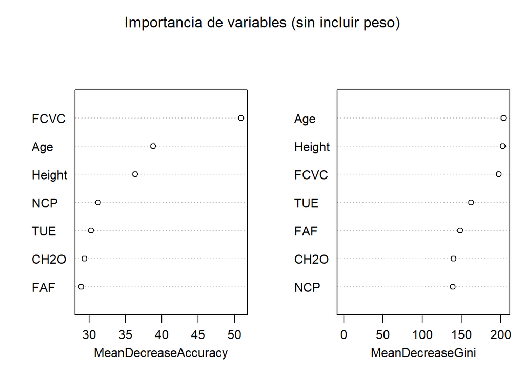

El modelo alcanzó una precisión del 83.5%, lo cual es notablemente alto considerando que se ha excluido una de las variables más informativas (el peso). Este rendimiento confirma que las variables relacionadas con estilo de vida y características personales (edad, altura, hábitos alimentarios, etc.) contienen información suficiente para predecir con éxito los niveles de obesidad.

# 6. Aplicación de SVM.

Las Máquinas de Vectores de Soporte (Support Vector Machines, SVM) son un tipo de modelo supervisado utilizado principalmente para clasificación. Su objetivo es encontrar una frontera óptima que separe las clases en base a las variables disponibles, maximizando el margen entre grupos.

**¿Por qué aplicar SVM en este caso?**

En el contexto de nuestro análisis, donde buscamos entender cómo los hábitos de vida se relacionan con distintos niveles de obesidad, SVM resulta especialmente útil por varias razones:

✔ Funciona bien cuando el número de variables explicativas es alto.

✔ Maneja correctamente relaciones no lineales entre las variables.

✔ Es robusto al sobreajuste si se parametriza correctamente y encuentra un margen óptimo.

Por tanto, entrenamos un modelo SVM para predecir la categoría de obesidad (NObeyesdad) a partir de variables como edad, altura, peso y hábitos alimenticios (frecuencia de comida saludable, actividad física, etc.).

```
## 'data.frame':    2111 obs. of  17 variables:
##  $ Gender                        : chr  "Female" "Female" "Male" "Male" ...
##  $ Age                           : int  21 21 23 27 22 29 23 22 24 22 ...
##  $ Height                        : num  1.62 1.52 1.8 1.8 1.78 1.62 1.5 1.64 1.78 1.72 ...
##  $ Weight                        : num  64 56 77 87 89.8 53 55 53 64 68 ...
##  $ family_history_with_overweight: chr  "yes" "yes" "yes" "no" ...
##  $ FAVC                          : chr  "no" "no" "no" "no" ...
##  $ FCVC                          : num  2 3 2 3 2 2 3 2 3 2 ...
##  $ NCP                           : num  3 3 3 3 1 3 3 3 3 3 ...
##  $ CAEC                          : chr  "Sometimes" "Sometimes" "Sometimes" "Sometimes" ...
##  $ SMOKE                         : chr  "no" "yes" "no" "no" ...
##  $ CH2O                          : num  2 3 2 2 2 2 2 2 2 2 ...
##  $ SCC                           : chr  "no" "yes" "no" "no" ...
##  $ FAF                           : num  0 3 2 2 0 0 1 3 1 1 ...
##  $ TUE                           : num  1 0 1 0 0 0 0 0 1 1 ...
##  $ CALC                          : chr  "no" "Sometimes" "Frequently" "Frequently" ...
##  $ MTRANS                        : chr  "Public_Transportation" "Public_Transportation" "Public_Transportation" "Walking" ...
##  $ NObeyesdad                    : chr  "Normal_Weight" "Normal_Weight" "Normal_Weight" "Overweight_Level_I" ...
```

#### División del dataset: entrenamiento y prueba

Para evaluar el rendimiento del modelo de forma realista, dividimos los datos en dos conjuntos: entrenamiento (70%) y prueba (30%). Esta división permite que el modelo aprenda con una muestra amplia pero sea validado sobre datos no vistos previamente.

**Distribución obtenida:**

- Entrenamiento: 1.479 observaciones
- Prueba: 632 observaciones.

La función createDataPartition() asegura que las proporciones de cada clase se mantengan equilibradas en ambos subconjuntos, lo que es crucial para evitar sesgos en el entrenamiento o en la evaluación del modelo.

```
## [1] 1479    8
```

```
## [1] 632   8
```

Entrenamiento con SVM lineal:

Aplicamos un modelo SVM con kernel lineal para evaluar si es posible separar los niveles de obesidad de forma sencilla, usando una frontera de decisión plana.

```
##
## Call:
## svm(formula = NObeyesdad ~ ., data = train, kernel = "linear", cost = 1)
##
##
## Parameters:
##    SVM-Type:  C-classification
##  SVM-Kernel:  linear
##        cost:  1
##
## Number of Support Vectors:  605
##
##  ( 113 151 89 141 51 46 14 )
##
##
## Number of Classes:  7
##
## Levels:
##  Insufficient_Weight Normal_Weight Obesity_Type_I Obesity_Type_II Obesity_Type_III Overweight_Level_I Overweight_Level_II
```

### ¿Qué significa esto?

- Tipo de modelo: Estamos usando un SVM de clasificación (C-classification) con un kernel lineal, lo que implica que el modelo intenta trazar líneas (o hiperplanos) que separen las categorías de obesidad en el espacio de variables.
- Parámetro cost = 1: Define la penalización por errores. Un valor bajo permite más errores pero evita sobreajuste; uno muy alto ajusta demasiado al entrenamiento. Aquí usamos un valor intermedio como punto de partida.
- Número de vectores de soporte: *605*. Estos son los puntos más cercanos a la frontera entre clases y son cruciales para definir el modelo. Que haya tantos sugiere que la separación entre categorías no es del todo clara.
- Distribución de soporte vectorial entre clases:

(113 151 89 141 51 46 14)

Algunas clases como Normal Weight o Obesity Type II requieren muchos vectores de soporte para ser separadas, lo que indica mayor complejidad en su clasificación. Otras, como Overweight Level II, parecen estar mejor delimitadas.

- Número de clases: El modelo está manejando 7 categorías distintas de obesidad. Esta granularidad permite una segmentación más fina, pero también aumenta la dificultad del problema de clasificación.

**En resumen:** aunque el modelo con kernel lineal da una primera aproximación, la elevada cantidad de vectores de soporte sugiere que la separación entre categorías no es del todo lineal. Por eso, como siguiente paso, probaremos kernels más flexibles como el radial y el polinómico, que permiten capturar relaciones no lineales entre variables y clases.

### Optimización de hiperparámetros con tune():

Ajustamos el parámetro cost del SVM con kernel lineal para mejorar el rendimiento del modelo. Esto nos permite encontrar el valor que mejor equilibra entre error y capacidad de generalización.

```
##
## Parameter tuning of 'svm':
##
## - sampling method: 10-fold cross validation
##
## - best parameters:
##  cost
##    10
##
## - best performance: 0.03920298
##
## - Detailed performance results:
##    cost      error dispersion
## 1  0.01 0.40230281 0.02822586
## 2  0.10 0.14061408 0.02166917
## 3  1.00 0.05880677 0.02381956
## 4  5.00 0.04325703 0.02428484
## 5 10.00 0.03920298 0.01552030
```

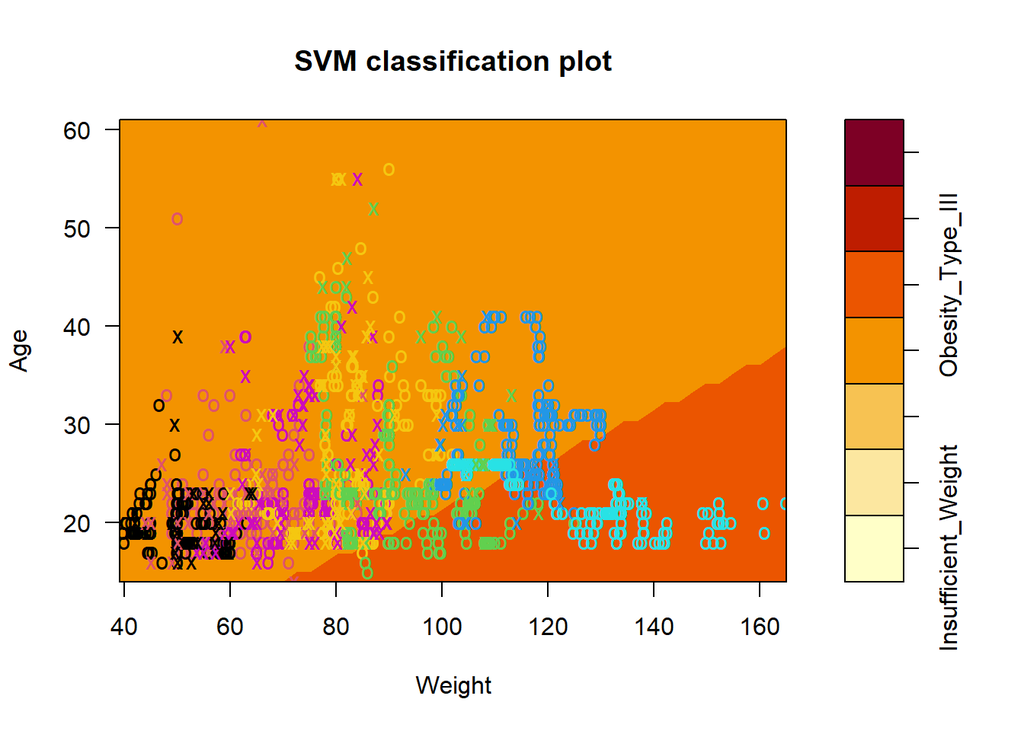

### *¿Qué nos indica la optimización con tune()?*

- El resultado de tune() muestra cómo varía el error del modelo en función del valor de cost.
- A medida que cost aumenta, el error de clasificación disminuye: el modelo se ajusta mejor, penalizando más los errores.
- El mejor resultado se obtiene con cost = 10, donde el error mínimo es 0.0392 con una desviación baja (0.0155). Este valor proporciona un buen compromiso entre precisión y generalización.
- En cambio, con valores bajos como cost = 0.01, el error es muy alto (0.4023), lo que indica que el modelo no consigue separar correctamente las clases.

### *¿Qué implica esto para nuestro problema?*

- Ajustar correctamente el parámetro cost es clave para obtener una clasificación eficaz de los distintos niveles de obesidad.
- Con cost = 10, el modelo logra una mejor diferenciación entre las clases, especialmente entre los extremos (como Insufficient Weight y Obesity Type III).
- Usar un valor inadecuado de cost lleva a modelos con poca capacidad discriminativa.

### *Interpretación del gráfico: clasificación según Edad y Peso*

La visualización del modelo SVM entrenado muestra cómo el algoritmo ha segmentado el espacio de variables para clasificar a los individuos en distintos niveles de obesidad.

Qué vemos en el gráfico:

- Eje X (Peso): refleja cómo varía el peso en la muestra.
- Eje Y (Edad): muestra la distribución por edades.
- Zonas de color: representan las fronteras de decisión que el SVM ha aprendido.
- Puntos: cada individuo del dataset, clasificado en una de las 7 categorías.

### Interpretación de los patrones:

En resumen: el ajuste del parámetro cost mejora notablemente la precisión del modelo SVM lineal. Sin embargo, como sigue habiendo cierta mezcla entre clases intermedias, exploraremos kernels más flexibles como el radial (RBF) y el polinómico para mejorar aún más la separación entre categorías.

### Evaluación del modelo SVM lineal optimizado:

Probamos el modelo ajustado (con cost = 10) sobre el conjunto de prueba para evaluar su capacidad de generalización:

```
##
## pr                    Insufficient_Weight Normal_Weight Obesity_Type_I
##   Insufficient_Weight                  81             4              0
##   Normal_Weight                         0            80              0
##   Obesity_Type_I                        0             0            102
##   Obesity_Type_II                       0             0              2
##   Obesity_Type_III                      0             0              0
##   Overweight_Level_I                    0             2              0
##   Overweight_Level_II                   0             0              1
##
## pr                    Obesity_Type_II Obesity_Type_III Overweight_Level_I
##   Insufficient_Weight               0                0                  0
##   Normal_Weight                     0                0                  2
##   Obesity_Type_I                    1                0                  0
##   Obesity_Type_II                  88                0                  0
##   Obesity_Type_III                  0               97                  0
##   Overweight_Level_I                0                0                 81
##   Overweight_Level_II               0                0                  4
##
## pr                    Overweight_Level_II
##   Insufficient_Weight                   0
##   Normal_Weight                         0
##   Obesity_Type_I                        1
##   Obesity_Type_II                       0
##   Obesity_Type_III                      0
##   Overweight_Level_I                    8
##   Overweight_Level_II                  78
```

```
## [1] "Precisión del modelo: 96.04 %"
```

### Resultados:

- Precisión total: el modelo alcanza una precisión del 96.04%, lo que indica un rendimiento muy alto en la clasificación de los distintos niveles de obesidad.
- Análisis de la matriz de confusión:
1. Las clases extremas como Insufficient Weight (81 casos correctamente clasificados) y Obesity Type III (97 casos correctos) no presentan errores, lo que sugiere que estas categorías están bien delimitadas en el espacio de variables.
2. En cambio, se observan errores mínimos entre clases cercanas:

### *Conclusión:*

- El modelo lineal con cost = 10 es altamente eficaz para esta tarea de clasificación multiclase.
- Las confusiones se dan principalmente entre categorías contiguas, lo que es esperable en problemas con clases progresivas (como niveles de obesidad).
- Aun así, para mejorar la separación de clases intermedias, conviene explorar kernels no lineales que capturen mejor las relaciones complejas.

### Comparativa de kernels: radial vs. polinómico:

Con el objetivo de capturar posibles relaciones no lineales en el dataset de obesidad, se probaron dos kernels alternativos al lineal: el kernel radial y el polinómico. La selección de estos kernels se basa en la relación entre el número de variables (p) y el número de observaciones (n).

```
##
## Call:
## best.tune(METHOD = svm, train.x = NObeyesdad ~ ., data = train, ranges = list(cost = c(0.01,
##     0.1, 1, 5, 10)), kernel = "radial")
##
##
## Parameters:
##    SVM-Type:  C-classification
##  SVM-Kernel:  radial
##        cost:  10
##
## Number of Support Vectors:  660
##
##  ( 136 146 111 135 66 50 16 )
##
##
## Number of Classes:  7
##
## Levels:
##  Insufficient_Weight Normal_Weight Obesity_Type_I Obesity_Type_II Obesity_Type_III Overweight_Level_I Overweight_Level_II
```

```
##
## Call:
## best.tune(METHOD = svm, train.x = NObeyesdad ~ ., data = train, ranges = list(cost = c(0.01,
##     0.1, 1, 5, 10), degree = c(2, 3, 4)), kernel = "polynomial")
##
##
## Parameters:
##    SVM-Type:  C-classification
##  SVM-Kernel:  polynomial
##        cost:  10
##      degree:  3
##      coef.0:  0
##
## Number of Support Vectors:  683
##
##  ( 129 152 136 154 54 47 11 )
##
##
## Number of Classes:  7
##
## Levels:
##  Insufficient_Weight Normal_Weight Obesity_Type_I Obesity_Type_II Obesity_Type_III Overweight_Level_I Overweight_Level_II
```

### *Parámetros seleccionados y soporte vectorial*

- Modelo con kernel radial:
1. cost = 10, kernel radial.
2. Vectores de soporte: 660 (Distribuidos en: 136, 146, 111, 135, 66, 50, 16)
- Modelo con kernel polinómico:
1. cost = 10, degree = 3
2. Vectores de soporte: 683 (Distribuidos en: 129, 152, 136, 154, 54, 47, 11)

### Interpretación:

1. Justificación teórica del uso de kernels
- Cuando *p < n* (pocas variables, muchas observaciones), es habitual que la separación entre clases no sea lineal. El kernel radial permite mapear los datos a un espacio de mayor dimensión, facilitando la separación mediante hiperplanos curvos.
- Cuando *p > n*, un kernel polinómico puede capturar relaciones complejas entre las variables sin necesidad de un mapeo explícito a espacios de alta dimensión. En estos casos, un grado polinómico adecuado permite modelar interacciones no triviales sin excesiva complejidad computacional.
2. Aplicación al dataset actual

En este caso, se cumple p < n: el número de variables predictoras es inferior al número de individuos en el conjunto de entrenamiento.

Por tanto, la utilización del kernel radial se ajusta mejor a la estructura del problema, al permitir una separación más flexible sin añadir demasiados parámetros al modelo.

3. Comparación práctica
- El modelo radial utiliza menos vectores de soporte que el polinómico (660 vs. 683), lo que puede indicar una mejor capacidad de generalización.
- El uso de degree = 3 en el modelo polinómico introduce una complejidad adicional que, aunque puede mejorar la adaptación local en algunos casos, también puede incrementar el riesgo de sobreajuste si no se controla adecuadamente.
- La penalización por errores (cost = 10) en ambos casos sugiere una preferencia por márgenes estrechos y baja tolerancia al error de clasificación.

### Conclusión:

El kernel radial se presenta como una opción más robusta para este conjunto de datos, dadas sus propiedades de mapeo no lineal y menor dependencia de hiperparámetros adicionales como el grado. Además, requiere menos vectores de soporte que el polinómico, lo que puede implicar una separación más natural entre clases sin necesidad de un ajuste excesivo.

### Conclusiones finales del análisis con SVM:

El análisis con Máquinas de Soporte Vectorial (SVM) aplicado al dataset de obesidad nos ha permitido comprobar la utilidad de este algoritmo para tareas de clasificación multiclase con datos que no siempre presentan una separación clara. A través de la comparación de distintos kernels y del ajuste del parámetro de penalización cost, hemos evaluado cómo se comporta el modelo frente a diferentes niveles de complejidad en los datos.

# 7. Aplicación de Regresión Logística

La regresión logística es un modelo estadístico tradicionalmente eficaz en tareas de clasificación binaria. En este caso, hemos tratado de aplicarlo a un problema de clasificación multiclase, intentando predecir el nivel de obesidad en función de variables relacionadas con el estilo de vida, alimentación y actividad física.

```
##
## log_class     Insufficient_Weight Normal_Weight Obesity_Type_I Obesity_Type_II
##   No_Obesidad                  81             3              0               0
##   Obesidad                      0            83            105              89
##
## log_class     Obesity_Type_III Overweight_Level_I Overweight_Level_II
##   No_Obesidad                0                  0                   0
##   Obesidad                  97                 87                  87
```

```
## [1] "Precisión del modelo de Regresión Logística: 25.95 %"
```

### Análisis del desempeño:

- Este modelo no distingue adecuadamente entre los distintos grados de obesidad, y en la práctica se comporta más como un clasificador binario.
- La estructura del problema es multiclase, por lo que una regresión logística estándar no es la herramienta adecuada a menos que se utilice en su forma multinomial (lo cual no se ha implementado aquí).
- Además, al simplificar las clases reales en solo dos, el modelo pierde capacidad para detectar diferencias sutiles pero importantes entre categorías intermedias como Overweight Level I y II o Obesity Type I y II.

### *Conclusión:*

La regresión logística, tal como fue aplicada, no es adecuada para este tipo de clasificación multiclase. Su bajo rendimiento confirma que necesitamos modelos más complejos y flexibles.

[output not shown]

### Regresión logística multinomial

# 8. Aplicación de Redes Neuronales (MLP)

Las redes neuronales multicapa (MLP) son un modelo potente para capturar patrones complejos en los datos, utilizando múltiples capas de neuronas interconectadas. Este enfoque permite modelar relaciones no lineales, lo que las convierte en una herramienta popular en problemas de clasificación avanzada. Sin embargo, su efectividad depende en gran medida de la correcta configuración y preprocesamiento de los datos.

```
##         Real
## Predicho   0   1
##        0 156   2
##        1   2 473
```

```
## [1] "Precisión de la Red Neuronal: 99.37 %"
```

### *Resultados del Modelo de Red Neuronal*

El modelo ajustado se basa en una arquitectura con dos capas ocultas, con 5 y 3 neuronas, respectivamente. El conjunto de entrenamiento consistió en el 70% de los datos, mientras que el 30% restante se usó para la prueba. La red neuronal fue entrenada para predecir la probabilidad de obesidad, con los valores de entrada normalizados entre 0 y 1.

- Matriz de Confusión:

Real//Predicho

- Precisión del modelo: 99.37%

### *Posibles Mejoras:*

1. Ajustar la Arquitectura: La estructura de la red, aunque aparentemente adecuada, podría beneficiarse de una revisión. Ampliar las capas ocultas o variar el número de neuronas podría mejorar la capacidad del modelo para generalizar mejor los patrones subyacentes.
2. Revisión de la Normalización de los Datos: Si bien las variables predictoras fueron normalizadas entre 0 y 1, es importante evaluar si este tipo de escalado es el más apropiado. Técnicas como la normalización Z-score pueden ser útiles en algunos casos.
3. Ampliar el Conjunto de Datos de Entrenamiento: Las redes neuronales, especialmente en problemas de clasificación complejos, tienden a necesitar grandes volúmenes de datos para entrenarse correctamente. Un conjunto de entrenamiento más grande podría ayudar a mejorar el desempeño del modelo.
4. Explorar Otros Modelos: Aunque las redes neuronales tienen su valor, otras técnicas como Random Forest o SVM podrían ofrecer un rendimiento superior, especialmente en problemas con relaciones no lineales y variables interdependientes complejas.

### Conclusión:

El modelo de red neuronal ajustado ha mostrado un desempeño sorprendentemente alto, pero esto no garantiza que sea el modelo más adecuado para este tipo de problema. A pesar de la alta precisión, los posibles problemas de sobreajuste y las limitaciones en la capacidad de generalización sugieren que podría ser necesario realizar ajustes adicionales en la arquitectura del modelo, así como en el preprocesamiento de los datos. Este resultado resalta que no todas las técnicas avanzadas son ideales para todos los problemas, y es crucial evaluar diversas aproximaciones y elegir la más adecuada según las características del conjunto de datos y los objetivos del análisis.

# 9. Comparativa entre modelos

Comparación de métricas por modelo

|  | Accuracy.Accuracy | Precision | Recall | F1 |
| --- | --- | --- | --- | --- |
| KNN | 0.8574 | 0.8589 | 0.8613 | 0.8505 |
| ConditionalTrees | 0.7598 | 0.7975 | 0.7749 | 0.7531 |
| RandomForest | 0.9339 | 0.9361 | 0.9315 | 0.9329 |
| RandomForestNoWeight | 0.8348 | 0.8408 | 0.8329 | 0.8353 |
| SVM | 0.9604 | 0.9596 | 0.9597 | 0.9593 |
| LogisticMultinomial | 0.9509 | 0.9509 | 0.9506 | 0.9504 |
| NeuralNetwork | 0.9937 | 0.9873 | 0.9873 | 0.9873 |
| NaiveBayes | 0.6625 | 0.6528 | 0.6701 | 0.6529 |

Comparación de Métricas por Modelo (incluyendo Regresión Logística)

| Modelo | Accuracy | Precision | Recall | F1 |
| --- | --- | --- | --- | --- |
| KNN | 0.8574 | 0.8589 | 0.8613 | 0.8505 |
| Conditional Trees | 0.7598 | 0.7975 | 0.7749 | 0.7531 |
| Random Forest | 0.9339 | 0.9361 | 0.9315 | 0.9329 |
| Random Forest (No Weight) | 0.8348 | 0.8408 | 0.8329 | 0.8353 |
| SVM | 0.9604 | 0.9596 | 0.9597 | 0.9593 |
| Logistic Multinomial | 0.9509 | 0.9509 | 0.9506 | 0.9504 |
| Logistic Regression | 0.2595 | 0.2850 | 0.2933 | 0.2391 |
| Neural Network | 0.9937 | 0.9873 | 0.9873 | 0.9873 |
| Naive Bayes | 0.6625 | 0.6528 | 0.6701 | 0.6529 |

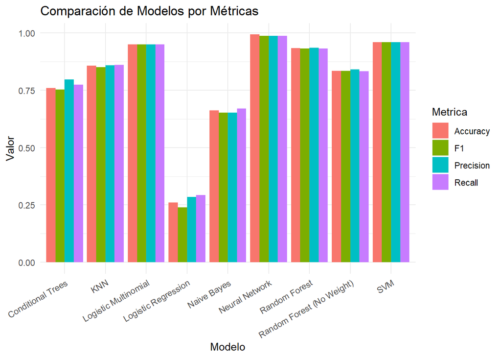

El gráfico muestra una comparación de distintos modelos de clasificación en función de cuatro métricas de evaluación: accuracy, F1, precision y recall. Cada barra representa el rendimiento de un modelo según una de estas métricas, lo que permite ver de forma clara cuáles modelos se comportan mejor y de manera más equilibrada.

La accuracy representa el porcentaje total de aciertos, es decir, cuántas veces el modelo acertó en su predicción sobre el total de casos evaluados. La precision indica, de entre todas las veces que el modelo predijo una determinada clase, cuántas veces acertó realmente; es útil para evitar falsos positivos. Por su parte, el recall (o sensibilidad) mide cuántas veces el modelo fue capaz de detectar correctamente una clase entre todos los casos reales de esa clase; ayuda a controlar los falsos negativos. Finalmente, la F1 es una media que equilibra precision y recall, y es especialmente útil cuando las clases están desbalanceadas.

Finalmente, los modelos de KNN y árboles condicionales (Conditional Trees) se sitúan en una zona intermedia: superan a Naive Bayes y la regresión logística binaria, pero están claramente por debajo de los modelos más complejos. En conjunto, el gráfico muestra que los modelos más avanzados, como redes neuronales, SVM y Random Forest, no solo son más precisos, sino también más equilibrados en su capacidad para clasificar correctamente todos los niveles de obesidad.